# COVID Is a Major Killer of Adults of All Ages

Nathan (Nat) Goodman

November 15, 2021

*COVID has killed more than 750,000 Americans to date, more than the 500,000 in the past 12 months. COVID is the third leading cause of death in the USA behind heart disease and cancer, and is 18% of expected deaths from all non-COVID causes. These numbers don’t seem to faze many people, perhaps because personal risk is low for most people: 0.16% for the USA as a whole, 0.08% for Washington State. In this blog post, I try to make the COVID death toll more concrete by comparing annual COVID deaths to expected non-COVID deaths and to other leading causes of death. I report on deaths for all ages in the United States and Washington State where I live, and deaths by age group in Washington State. See below for data sources, and caveats and technical details.*

The gruesome body count of COVID deaths is mind-numbing. Unless you’ve lost a loved one to COVID or provided care to seriously ill COVID patients, it’s hard to grasp the enormity of the death toll: 700,000 deaths reported in the New York Times on October 1, a number that’s grown to more than 750,000 as I write this. For those who remember the Vietnam war, it brings to mind the body counts reported daily to mark “progress” in that horror. For comparison, the official US death toll in the Vietnam war was 58,220; Vietnamese deaths probably exceeded 1,000,000.

The basic COVID paradox is that personal risk for most people is low, even though the death count is high. The first block of figures show risk for people of all ages in the USA and Washington State (Figure 1a) and by age group in Washington State (Figure 1b).

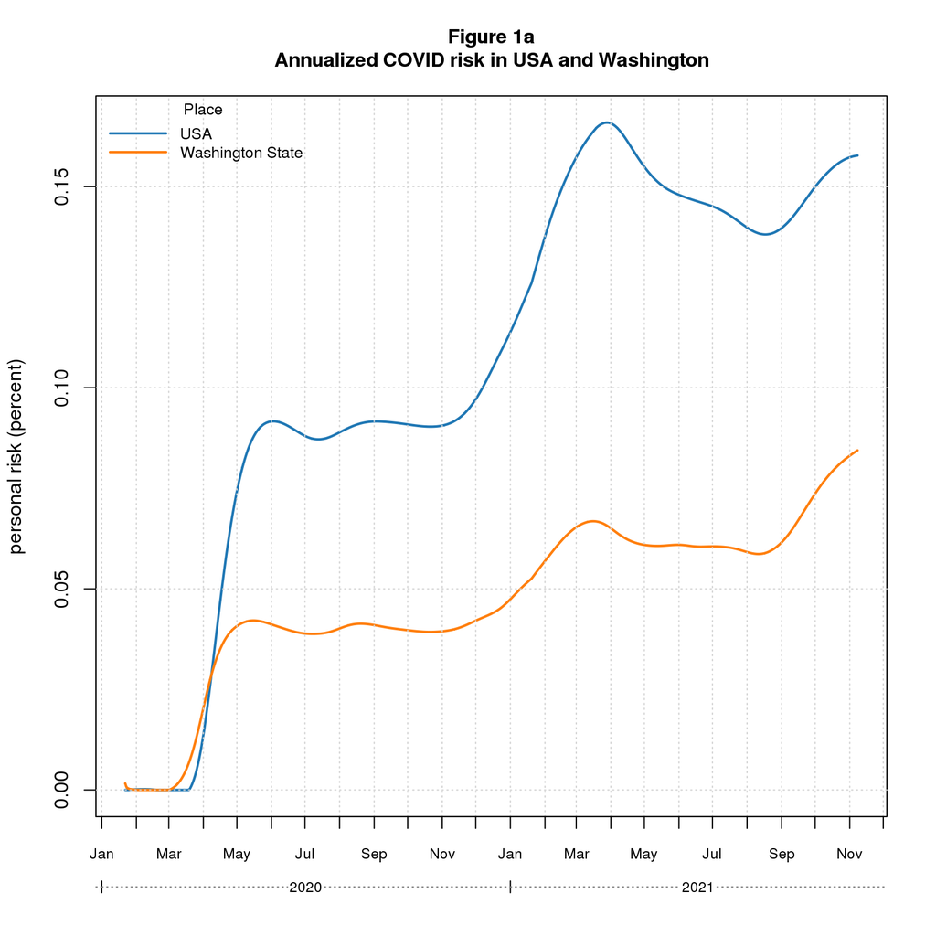

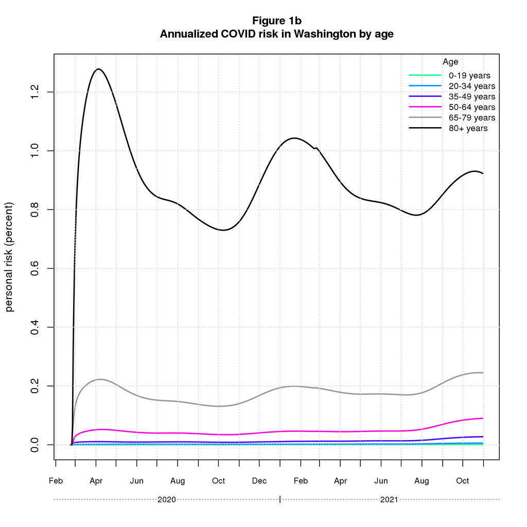

The next block of figures (Figures 2a-b) compare COVID deaths to expected non-COVID deaths.

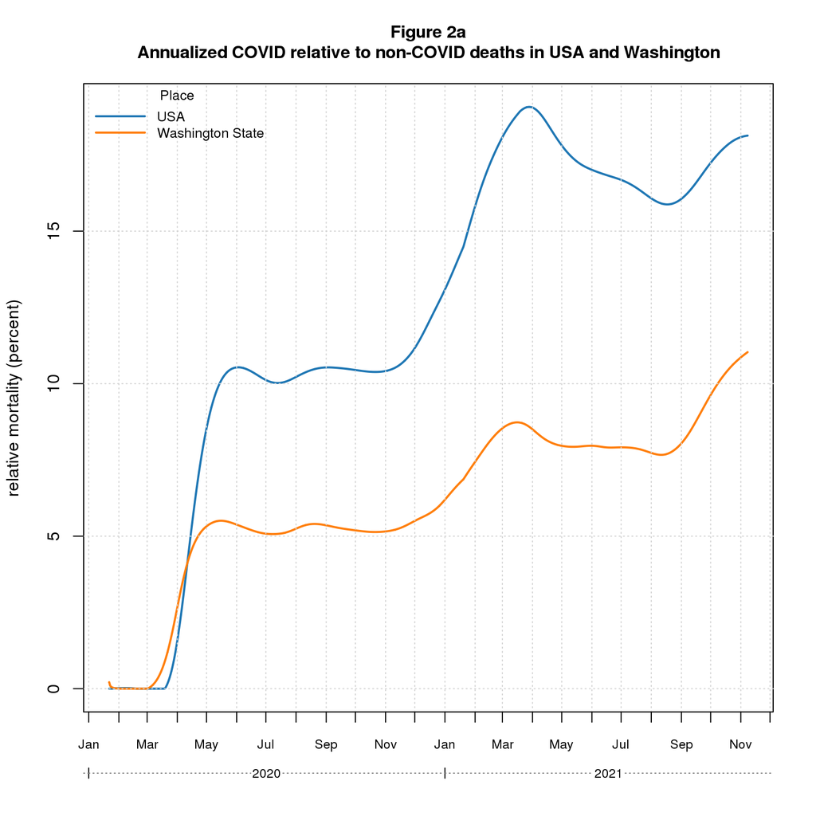

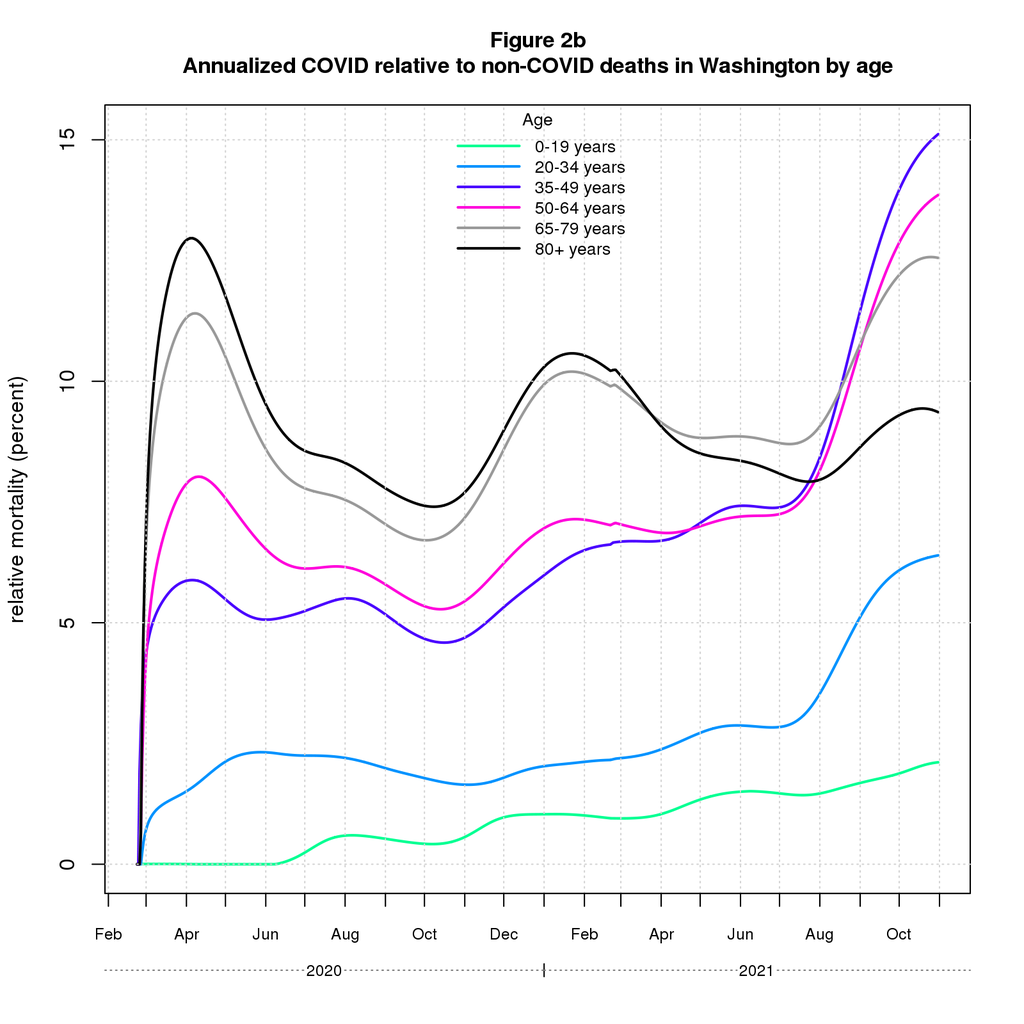

For the all-age data (Figure 2a), this is just a simple scaling and doesn’t change the shape of the graphs much. If you look closely, you’ll notice that the graphs are a little closer together. This is because mortality is a little higher in the USA than Washington State; equivalently, life expectancy is higher in Washington than the country as a whole.

For data by age group (Figure 2b), the change is dramatic. The elderly (80+ years) are now in the middle of the pack. The most affected groups are middle aged adults (35-49 years), followed by pre-seniors (50-64 years), and then young seniors (65-79 years). Young adults (20-34 years) and children and teens (0-19 years) remain thankfully near the bottom but have moved much closer to the older groups.

The reason for the big change in the age-group figures is that expected mortality is much lower in younger groups making COVID deaths a bigger fraction of the total.

Relative mortality captures the sense that while all deaths are sad, deaths in young people are more tragic. Sayings like, “Cut down in their prime”, “Died before their time”, “Outlived their children” express the grief we feel when people die too young. By this measure, COVID’s impact on adults 35-79 years old is greater than in the elderly (80+ years), even though the absolute death rate is much higher in the elderly.

The table below summarizes the results so far.

Annualized COVID deaths relative to population and expected non-COVID deaths

| Location/Age | Deaths | Deaths per Million | Personal Risk | Relative Mortality |
| --- | --- | --- | --- | --- |
| USA all ages | 517663 | 1577 | 0.16% | 18% |
| WA all ages | 6429 | 844 | 0.084% | 11% |
| WA 0-19 years old | 15 | 8 | 0.00083% | 2% |
| WA 20-34 years old | 93 | 57 | 0.0057% | 6% |
| WA 35-49 years old | 412 | 274 | 0.027% | 15% |
| WA 50-64 years old | 1273 | 899 | 0.09% | 14% |
| WA 65-79 years old | 2320 | 2450 | 0.24% | 13% |
| WA 80+ years old | 2404 | 9228 | 0.92% | 9% |

The main points of note are

1. Personal risk for the USA as a whole is almost double the risk in Washington State (0.16% vs 0.084%).
- Relative mortality is higher in the USA than Washington, too, but not by as much (18% vs 11%).
2. Personal risk for an elderly person (80+ years) in Washington State is nearly 1% per year, dropping to about 0.006% for a young adult (20-34 years), and even further to under 0.001% for a child or teen (0-19 years).
- Relative mortality has a different trajectory: lowest in the young, greatest in middle aged adults (35-49 years), then falling group by group to 9% in the elderly (80+ years).

The tables below gives further context for these numbers by comparing annual COVID deaths to the leading non-COVID causes of death.

USA all ages

| Cause | Deaths per Million |
| --- | --- |
| heart disease | 2008 |
| cancer | 1827 |
| **COVID** | 1577 |
| accident | 527 |
| lung disease | 478 |
| stroke | 457 |

WA all ages

| Cause | Deaths per Million |
| --- | --- |
| cancer | 1702 |
| heart disease | 1558 |
| **COVID** | 844 |
| Alzheimer | 471 |
| accident | 469 |
| lung disease | 400 |

COVID is the third leading cause of death in the USA as a whole, killing almost as many people as cancer and more than the next three causes (accidents, lung disease, and stroke) together. COVID is also the third leading cause of death in Washington State all ages but sits well below the top two causes (cancer and heart disease) and well above the next three (Alzheimer’s disease, accidents, and lung disease).

The next tables show results for Washington State by age group.

WA 0-19 years old

| Cause | Deaths per Million |
| --- | --- |
| perinatal condition | 91 |
| accident | 68 |
| congenital condition | 59 |
| suicide | 37 |
| cancer | 23 |
| **COVID** | 8 |

WA 20-34 years old

| Cause | Deaths per Million |
| --- | --- |
| accident | 352 |
| suicide | 177 |
| cancer | 57 |
| **COVID** | 57 |
| homicide | 48 |
| heart disease | 35 |

WA 35-49 years old

| Cause | Deaths per Million |
| --- | --- |
| accident | 387 |
| cancer | 323 |
| **COVID** | 274 |
| heart disease | 220 |
| suicide | 209 |
| liver disease | 116 |

WA 50-64 years old

| Cause | Deaths per Million |
| --- | --- |
| cancer | 1964 |
| heart disease | 1171 |
| **COVID** | 899 |
| accident | 513 |
| liver disease | 365 |
| lung disease | 278 |

WA 65-79 years old

| Cause | Deaths per Million |
| --- | --- |
| cancer | 5952 |
| heart disease | 3759 |
| **COVID** | 2450 |
| lung disease | 1425 |
| stroke | 877 |
| diabetes | 814 |

WA 80+ years old

| Cause | Deaths per Million |
| --- | --- |
| heart disease | 23733 |
| cancer | 14916 |
| Alzheimer | 11468 |
| **COVID** | 9228 |
| stroke | 7031 |
| lung disease | 4801 |

Among children and teens in Washington State (0-19 years), COVID thankfully remains below the five leading causes of death. It climbs to fourth place in the next age group (young adults, ages 20-34 years) where it kills almost as many people as cancer and more than homicide and heart disease. COVID is the third leading killer for the next three age groups (35-49, 50-64, and 65-79 years). In the elderly (80+ years), the death rates are much higher for all leading causes; in this group, Alzheimer’s disease overtakes COVID which sits as the fourth leading cause of death.

COVID is a major killer of adults of all ages. In the USA as a whole, it kills almost as many as cancer. In Washington State, COVID kills almost as many people as cancer in adults 20-49 years old, almost as many as heart disease in adults 50-79 years old, and almost as many as Alzheimer’s disease in adults 80+ years old. In the USA as a whole, COVID accounts for 18% of non-COVID deaths. In Washington State, COVID deaths are 11% of non-COVID deaths for people of all ages, ranging from 6% in adults 20-34 years old, increasing to 15% in the next older group (35-49 years), and dropping group-by-group to 9% in the elderly (80+ years).

People’s emotional response to the risk of death is often colored by their perceived personal risk and their experience with deaths of people they know. For most people, the risk is low. And even though the risk for old people is high, COVID is such a new disease that most people have yet to experience a COVID death in their loved ones. This will change if COVID persists, of course, but for now it’s easy for many people to shrug off COVID danger.

I hope that placing COVID in the context of other deadly diseases will make the enormous COVID death toll more concrete. I don’t expect to change the minds of people who don’t care. But perhaps I can help people who do care to better understand this ongoing tragedy.

### Data Sources and References

1. COVID data for USA and Washington State all ages is from Johns Hopkins University (JHU) [COVID portal](https://github.com/CSSEGISandData/COVID-19/), specifically their time_series_covid19_deaths_US.csv.
2. COVID data for Washington State age groups is from Washington State Department of Health (DOH) [COVID-19 Data Dashboard](https://www.doh.wa.gov/Emergencies/COVID19/DataDashboard), specifically the weekly download file available on that page.
3. Population data for personal risk calculation is from [Census Reporter](https://censusreporter.org). I use their 2019 population estimates.
4. Mortality data, including leading causes of death, are from [CDC Wonder](https://wonder.cdc.gov/ucd-icd10-expanded.html) for 2019. If you query CDC Wonder, you may find their mortality rates differ slightly from the tables here. That’s because they use slightly different population estimates from the Census Reporter estimates I use. CDC Wonder uses medically accurate [ICD-10 codes](https://www.icd10data.com/ICD10CM/Codes) for causes of death; I translate these into approximately equivalent lay terms.

Note that population and mortality data are for 2019, the last pre-COVID year. COVID data is current: 2020-21.

### Caveats and Technical Details

**Processing COVID data**

1. DOH systematically under counts recent events due to manual curation. I attempt to correct this undercount through linear extrapolation (R’s `lm`) using a model that combines date and recentness effects.
2. JHU reports daily cumulative counts, while DOH reports weekly incremental counts. I compute cumulative counts for DOH by summing the data to-date using R’s `cumsum`. I apply this conversion after the extrapolation above.
3. I fit each data source to a smoothing spline (R’s `smooth.spline`) for visual appeal and to interpolate DOH weekly data to individual days.
4. **Annualization**. For dates in the first 365 days of the data series (January 22, 2020 to January 20, 2021), I scale the counts to 365 days: $deaths(date)*(365/elapsed\ days)$. For later dates, I use the actual counts of the 365 days ending on that date: $deaths(date)-deaths(date-364)$.

## Comments Please!

Please post comments on LinkedIn or [Twitter](https://twitter.com/gnatgoodman).

## Copyright & License

Copyright (c) 2021 Nathan Goodman

This document is **open access**, released under the [Creative Commons Attribution 4.0 International License](https://creativecommons.org/licenses/by/4.0)

The software used to generate the results is **open source and free**, released under the [MIT License](https://opensource.org/licenses/MIT) and available from my [COVID repository on GitHub](https://github.com/natgoodman/covid).